# Planejamento e Análise de Experimentos II -atividade I

joseferson da silva barreto

20/12/2021

## Objeivo

Realizar um Delineamento Completamente Casualizado em Blocos (DBC) afim de solucionar a questão a baixo

## Questão proposta

Sejam os dados de um experimento, em blocos casualizados, no esquema fatorial 3 × 3, em que, foram estudados os efeitos de 3 Peneiras comerciais, associadas a 3 Densidades de plantio, na produtividade do amendoim (Arachis hypogaea L.) variedade Tatu V53. As Peneiras comerciais (P) e as Densidades de plantio (D) estudadas foram:

$P_1=$ peneira 18 (crivos circulares com diâmetro de 18/64 polegadas);

$P_2=$peneira 20 (crivos circulares com diâmetro de 20/64 polegadas);

$P_3=$ peneira 22 (crivos circulares com diâmetro de 22/64 polegadas);

$D_1 =$ 10 plantas por metro linear;

$D_2 =$ 15 plantas por metro linear;

$D_3 =$ 20 plantas por metro linea.

**Tabela:** Dados da produção média de amendoim em vargem (g) por planta:

|  | Tratamentos | Bloco 1 | Bloco 2 | Bloco 3 | Totais |
| --- | --- | --- | --- | --- | --- |
| 1 | 1-P1D1 | 11.82 | 12.03 | 12.55 | 36.4 |
| 2 | 2-P1D2 | 12.34 | 14.08 | 12.13 | 38.55 |
| 3 | 3-P1D3 | 13.41 | 12.98 | 12.35 | 39.74 |
| 4 | 4-P2D1 | 6.97 | 10.96 | 9.02 | 26.25 |
| 5 | 5-P2D2 | 8.96 | 9.02 | 9.84 | 27.82 |
| 6 | 6-P2D3 | 8.48 | 9.66 | 8.5 | 26.64 |
| 7 | 7-P3D1 | 7.53 | 7.67 | 7.81 | 23.01 |
| 8 | 8-P3D2 | 6.71 | 7.87 | 9.49 | 24.07 |
| 9 | 9-P3D3 | 7.82 | 9.44 | 9.37 | 26.63 |
| 10 | Totais | 84.04 | 93.01 | 92.06 | 269.11 |

## Croqui do experimento

Vamos montar o delineamento em blocos casualisados , definindo algumas varáveis como :

**b:** receberá o número de blocos do experimento

**t:** receberá o número de tratamentos

**n:** será o número de observações vezes , ou seja , números de blocos vezes o número de tratamentos

**parcelas:** receberá o número de parcelas do experimento

**Trat:** irá receber o número de tratamentos em nosso experimento

**aninhamento:** irá receber os blocos da variável parcela.

```r
require(dae)


b <- 3     # n?mero de blocos
t <- 9     # n?mero de tratamentos
n <- b*t   # n?mero de observa??es

parcelas <- list (Bloco = b, parcelas = t)
aninhamento <- list (parcelas = "Bloco")
trat <- factor(rep(c(1:t), times=b), labels=c("P1D1","P1D2","P1D3","P2D1",
                "P2D2","P2D3","P3D1","P3D2","P3D3"))
## P = As Peneirascomerciais 3 níveis
##D = as Densidades de plantio com 3 níveis

planta<- data.frame(fac.gen(parcelas), trat) # basic systematic layout
DBC_fat <-fac.layout(unrandomized = parcelas,
                    nested.factors = aninhamento,
                        randomized = trat, seed=311)
```

|  | .Units | .Permutation | Bloco | parcelas | trat |
| --- | --- | --- | --- | --- | --- |
| 1 | 1 | 17 | 1 | 1 | P2D2 |
| 2 | 2 | 10 | 1 | 2 | P2D3 |
| 3 | 3 | 15 | 1 | 3 | P2D1 |
| 4 | 4 | 14 | 1 | 4 | P3D3 |
| 5 | 5 | 12 | 1 | 5 | P1D2 |
| 6 | 6 | 18 | 1 | 6 | P3D1 |
| 7 | 7 | 11 | 1 | 7 | P3D2 |
| 8 | 8 | 13 | 1 | 8 | P1D3 |
| 9 | 9 | 16 | 1 | 9 | P1D1 |
| 10 | 10 | 21 | 2 | 1 | P1D2 |

[output cut: 17 more lines]

## Análise dos dados

**Y=** recebe todas as parcelas do experimento ;

**n=** Recebe o número de níveis de Densidades de plantio;

**K=** Recebe número de níveis Peneiras comerciais ;

**Bloco=** Recebe os níveis dos Bloco

**peneira=** Recebe os níveis fator peneiras comerciais ;

**densidade=** Recebe os níveis do fator densidade ;

**trat=** Recebe os níveis dos tratamentos ;

**parcelas=** recebe o números de parcelas indo de 1 a T(**27**) ;

```r
y<- c(11.82,12.03   ,12.55,
12.34,  14.08,  12.13,
13.41,  12.98,  12.35,
6.97,   10.96,  9.02,
8.96,   9.02    ,9.84,
8.48,   9.66,   8.5,
7.53,   7.67    ,7.81,
6.71,   7.87,   9.49,
7.82,   9.44,   9.37)
n = length(y)
t = 9
b = 3

bloco<- factor(rep(c("B1","B2","B3"),time=c(t,t,t)))
parcelas<- factor(rep(c(1:t), time=b))
### Combina??es de Tratamentos
k = 3   # k = numero de níveis Peneiras comerciais
j =3   # j = numero de níveis de Densidades de plantio
peneira<- factor(rep(c(1:k), each=j, times=b), labels=c("P1","P2","p3"))
densidade<- factor(rep(c(1:j), times= k*b), labels=c("D1","D2","D3"))
trat<- factor(rep(c(1:t), time=b), labels=c("T1","T2","T3","T4","T5","T6","T7","T8","T9"))

DBC<- data.frame(parcelas,bloco,peneira,densidade,trat,y)
```

[output not shown]

[output cut: 17 more lines]

## Análise descritiva

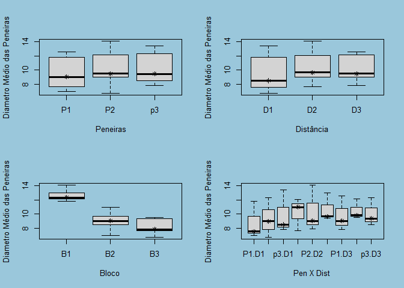

# gráficos de interação

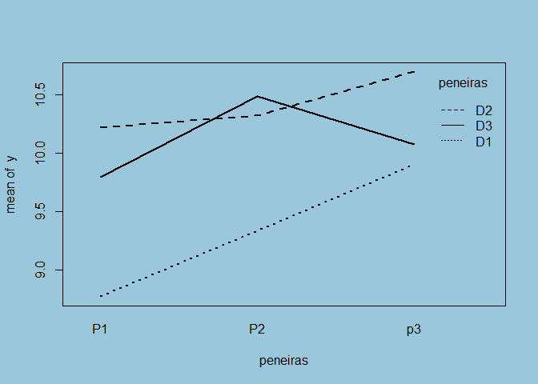

```r
par(bg = '#9ac7db')
interaction.plot(peneira,densidade,y, lwd=2,
                xlab = "peneiras",
                trace.label ="peneiras")
```

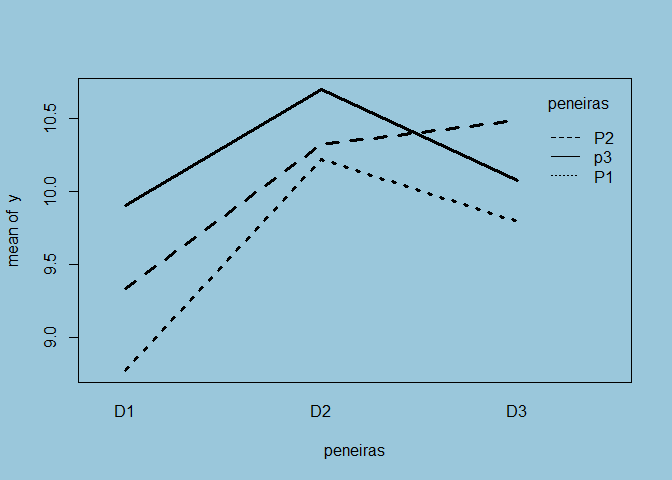

```r
par(bg = '#9ac7db')
interaction.plot(densidade,peneira,y, lwd=3,
                xlab = "peneiras",
                trace.label ="peneiras")
```

# média, variância e erro padronizado

```r
Var_esp<-  tapply(y,peneira,var)
Var_dist<- tapply(y,densidade,var)
Var_trat<- tapply(y,trat,var)

Media_esp<-  tapply(y,peneira,mean)
Media_dist<- tapply(y,densidade,mean)
Media_trat<- tapply(y,trat,mean)

Desvio_pad_esp<- sqrt(Var_esp)
Desvio_pad_dist<- sqrt(Var_dist)
Desvio_pad_trat<- sqrt(Var_trat)

V_esp<-data.frame(Var_esp, Media_esp, Desvio_pad_esp);
```

|  | Var_esp | Media_esp | Desvio_pad_esp |
| --- | --- | --- | --- |
| P1 | 4.98155277777778 | 9.59555555555556 | 2.23193924150676 |
| P2 | 5.54076111111111 | 10.0488888888889 | 2.3538821361978 |
| p3 | 4.465125 | 10.2233333333333 | 2.1130842387373 |

```r
V_dist<- data.frame(Var_dist, Media_dist, Desvio_pad_dist);
```

|  | Var_dist | Media_dist | Desvio_pad_dist |
| --- | --- | --- | --- |
| D1 | 6.33994444444444 | 9.33777777777778 | 2.51792463041379 |
| D2 | 5.04941944444445 | 10.4122222222222 | 2.24709132979602 |
| D3 | 3.14076944444445 | 10.1177777777778 | 1.7722216126784 |

```r
V_trat<- data.frame(Var_trat, Media_trat, Desvio_pad_trat);
```

|  | Var_trat | Media_trat | Desvio_pad_trat |
| --- | --- | --- | --- |
| T1 | 7.04003333333333 | 8.77333333333333 | 2.65330611376323 |
| T2 | 5.1631 | 10.22 | 2.27224558531863 |
| T3 | 6.06543333333334 | 9.79333333333333 | 2.46281004816314 |
| T4 | 8.03063333333333 | 9.33666666666667 | 2.83383721009753 |
| T5 | 10.9150333333333 | 10.3233333333333 | 3.30379075205034 |
| T6 | 2.05603333333333 | 10.4866666666667 | 1.43388748977503 |
| T7 | 9.33143333333333 | 9.90333333333333 | 3.05473948698303 |
| T8 | 3.93373333333333 | 10.6933333333333 | 1.98336414541892 |
| T9 | 4.07663333333333 | 10.0733333333333 | 2.01906744150198 |

aditividade ok !

# Definindo o nosso modelo

```r
#usando lm (vari?vel adicionada (gama)u - ver caderno!!!)
planta.lm <- lm(y ~ bloco + peneira*densidade)
anova(planta.lm , test="F")
```

```
## Analysis of Variance Table
##
## Response: y
##                   Df Sum Sq Mean Sq F value    Pr(>F)
## bloco              2 99.988  49.994 60.4358 3.487e-08 ***
## peneira            2  1.890   0.945  1.1425   0.34373
## densidade          2  5.549   2.774  3.3537   0.06076 .
## peneira:densidade  4  1.127   0.282  0.3405   0.84663
## Residuals         16 13.236   0.827
## ---
## Signif. codes:  0 '***' 0.001 '**' 0.01 '*' 0.05 '.' 0.1 ' ' 1
```

```r
LP2 <- (predict(planta.lm))^2      # = u
planta.lm2 <-update(planta.lm, .~. +LP2) # ajustando o novo modelo com a vari?vel adicionada
anova(planta.lm, planta.lm2, test="F")
```

```
## Analysis of Variance Table
##
## Model 1: y ~ bloco + peneira * densidade
## Model 2: y ~ bloco + peneira + densidade + LP2 + peneira:densidade
##   Res.Df    RSS Df Sum of Sq      F Pr(>F)
## 1     16 13.236
## 2     15 12.309  1   0.92638 1.1289 0.3048
```

comparando os 2 modelos!

Portanto não se rejeita Ho: (gama)=0, ou seja, existem evidências de aditividade do modelo.

# Teste de homogenidade fmax

## Hipóteses :

$H_0$:**as variâncias são homogêneas**

$H_1$:**as variâncias não são homogêneas**

Devemos ver o F na tabela do **F-máximo_tab(K,v)**: **k** estimativas de variâncias com **v** graus de liberdade cada uma (repetição ou blocos)

$F_(tab_)$(5%,9,3) = 93.90

```r
F_cal = max(Var_trat)/min(Var_trat);
F_cal
```

```
## [1] 5.308782
```

Assim, $F_(cal_)<F_(tab_)$ aceita-se $H_o$, logo as variâncias são homogeneas!.

### Gráficos para checar o diagnostico (suposições) :

### valores ajustados

fit = valores ajustados

res = resíduos ordinários

res_padronizado = resíduos padronizados

res_student = resíduo studentizado

```r
fit            <- fitted(planta.lm)

res            <- residuals(planta.lm)


res_padronizado<- rstandard(planta.lm)


res_student    <- rstudent(planta.lm)
```

# Montando o data frame

```r
ajustados<-data.frame(parcelas, trat, y, res, res_padronizado, res_student, fit)
```

|  | parcelas | trat | y | res | res_padronizado | res_student | fit |
| --- | --- | --- | --- | --- | --- | --- | --- |
| 1 | 1 | T1 | 11.82 | 0.3704 | 0.529 | 0.5167 | 11.4496 |
| 2 | 2 | T2 | 12.03 | -0.8663 | -1.2373 | -1.2598 | 12.8963 |
| 3 | 3 | T3 | 12.55 | 0.0804 | 0.1148 | 0.1112 | 12.4696 |
| 4 | 4 | T4 | 12.34 | 0.327 | 0.4671 | 0.4554 | 12.013 |
| 5 | 5 | T5 | 14.08 | 1.0804 | 1.5431 | 1.6194 | 12.9996 |
| 6 | 6 | T6 | 12.13 | -1.033 | -1.4753 | -1.5369 | 13.163 |
| 7 | 7 | T7 | 13.41 | 0.8304 | 1.186 | 1.2024 | 12.5796 |
| 8 | 8 | T8 | 12.98 | -0.3896 | -0.5565 | -0.5441 | 13.3696 |
| 9 | 9 | T9 | 12.35 | -0.3996 | -0.5708 | -0.5584 | 12.7496 |
| 10 | 1 | T1 | 6.97 | -0.893 | -1.2754 | -1.3029 | 7.863 |

[output cut: 17 more lines]

### Verificando a homogenidade das variâncias

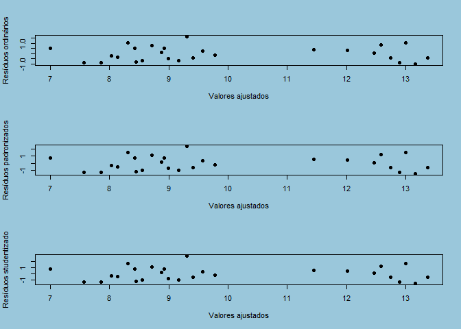

```r
par(bg = '#9ac7db')
par(mfrow=c(3,1))
plot(fit, res            , pch=16, xlab='Valores ajustados', ylab='Resíduos ordinários')
plot(fit, res_padronizado, pch=16, xlab='Valores ajustados', ylab='Resíduos padronizados')
plot(fit, res_student    , pch=16, xlab='Valores ajustados', ylab='Resíduos studentizado')
```

### verifica a Homogeneidade de var entre trat dentro dos blocos

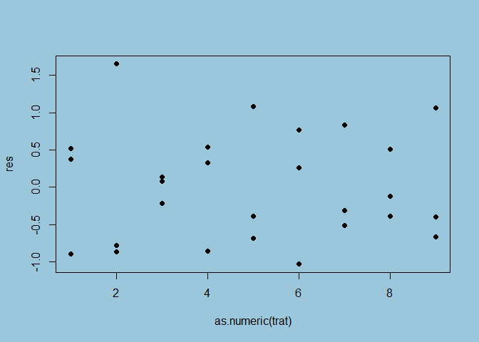

```r
par(bg = '#9ac7db')
plot(as.numeric(trat), res, pch = 16)
```

# Normalidados erros

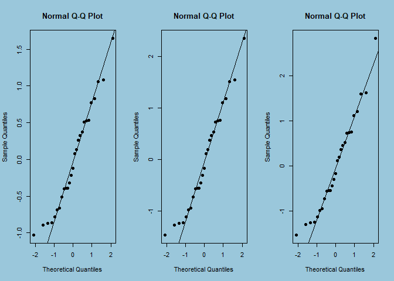

```r
#3) Normalidade dos erros : ok!
par(bg = '#9ac7db')
par(mfrow=c(1,3))
qqnorm(res, pch=16);                qqline(res)
qqnorm(res_padronizado, pch=16);    qqline(res_padronizado)
qqnorm(res_student, pch=16);        qqline(res_student)
```

Normal Q-Q) mostra que os pontos não fogem acentuadamente uma reta, indicando que a suposição de normalidade dos erros foi atendida.

# Teste de normalidade dos residuos ( Shapiro-Wilk )

Vamos começar analisando o resultado do teste de normalidade de resíduos(Shapiro-Wilk)

## hipóteses:

$H_0 :$ existe normalidade nos resíduos para $P \ge 0,05$

$H_1 :$ não existe normalidade dos resíduos $P < 0,05$

```r
shapiro.test(planta.lm$res)
```

```
##
##  Shapiro-Wilk normality test
##
## data:  planta.lm$res
## W = 0.95527, p-value = 0.2869
```

De acordo com o teste de Shapiro-Wilk a 5% de significancia,não rejeita-se a hipótese nula,logo, os residuos podem ser considerados normais.

# Independência das observações

## Dificil de ser verificada…gráfico de indice

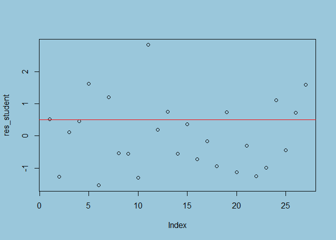

```
## integer(0)
```

```r
# 4) Independ?ncia das observa??es
# Dificil de ser verificada...gr?fico de indice
par(bg = '#9ac7db')

plot(res_student)
abline(h=0.5,col="red")
identify(res_student)
```

# Contruindo a anova do zero

```r
Xg<- model.matrix(lm(y~1));            # Xg
Xb<- model.matrix(lm(y~bloco-1));      #Xb
# Xu<- model.matrix(lm(y~parcelas-1));   # Xu    # Xu = Xpb
  XA<- model.matrix(lm(y~peneira-1));    # XA    # fator A: especie
  XB<- model.matrix(lm(y~densidade-1));  # XB    # fator B: espa?amento
  Xt<- model.matrix(lm(y~trat-1));        #Xt    # trat = A*B




# Operadores de M?dias
Mg<- Xg %*% solve(t(Xg) %*% Xg) %*% t(Xg);   #fractions(Mg)
Mb<- Xb %*% solve(t(Xb) %*% Xb) %*% t(Xb);   #fractions(Mb)
Mu <- diag(1,n,n);# Mu # Mu<- Xu %*% solve(t(Xu) %*% Xu) %*% t(Xu);   fractions(Mu)
  MA<- XA %*% solve(t(XA) %*% XA) %*% t(XA);   #fractions(MA)
  MB<- XB %*% solve(t(XB) %*% XB) %*% t(XB);  # fractions(MB)
  Mt<- Xt %*% solve(t(Xt) %*% Xt) %*% t(Xt);   #fractions(Mt)





  #  M?dias
G_barra<- Mg %*% y ;   # G_barra  # Fi estimado de G  (n?o existe diferen?a de bloco ou tratamento)
B_barra<- Mb %*% y ;  #  B_barra  # Fi estimado de B  (diferen?a somente de blocos)
T_barra<- Mt %*% y ;    #T_barra  # Fi estimado de T  (diferen?a de tratamentos)
S<-B_barra + T_barra - G_barra      # Fi estimado de B+T  (diferen?a de blocos e tratamentos) = modelo estimado

# Matrizes N?cleo
Qb<-     Mb - Mg
Qpb<-    Mu - Mb
    QA<- MA - Mg
    QB<- MB - Mg
    Qt<-     Mt - MA - MB + Mg
    Qures<- (Mu-Mb) - (MA-Mg) - (MB-Mg) - (Mt-MA-MB+Mg)   # Qures = Qpb-QA-QB-Qt
Qu<-     Mu - Mg                    # total




#  Desvios
Be<- Qb %*% y ; #Be
Db<-  Qpb%*% y ;   # Db
      Ae<-   QA %*% y ;   # Ae
      Be<-   QB %*% y ;   # Be
      Te<-   Qt %*% y ;   # Te
      Dbt<-  Qures %*% y ;   # Dbt
Dg<-   Qu %*% y ;   # Dg






# Somas de Quadrados
SQBloc <- t(y) %*% Qb    %*% y; # SQBloc
SQpb   <- t(y) %*% Qpb   %*% y;  #SQpb
    SQA<- t(y) %*% QA    %*% y; # SQA
    SQB<- t(y) %*% QB    %*% y;  #SQB
    SQTrat<- t(y) %*% Qt    %*% y;  #SQTrat  # SQA*B
    SQRes <- t(y) %*% Qures %*% y; # SQRes
SQTotal<- t(y) %*% Qu %*% y;  #SQTotal






# Graus de Liberdade
gl_bloc<-  sum(round(eigen(Qb)   $value,1));   # gl_bloc
gl_pb  <-  sum(round(eigen(Qpb)   $value,1));   #gl_pb
    gl_A<-     sum(round(eigen(QA)   $value,1)); # gl_A
    gl_B<-     sum(round(eigen(QB)   $value,1));  #gl_B
    gl_trat<-  sum(round(eigen(Qt)   $value,1));  #gl_trat
    gl_res <-  sum(round(eigen(Qures)$value,1));  #gl_res




# Quadrados M?dios
QMBloc <- SQBloc/gl_bloc; # QMBloc
    QMA<- SQA/gl_A;         # QMA
    QMB<- SQB/gl_B;          #QMB
    QMTrat<- SQTrat/gl_trat; #QMTrat
    QMRes <- SQRes/gl_res;   #QMRes

# F
F_calc_b<- QMBloc/QMRes;   #F_calc_b
    F_calc_A<- QMA/QMRes;    #  F_calc_A
    F_calc_B<- QMB/QMRes;     # F_calc_B
    F_calc_T<- QMTrat/QMRes;  # F_calc_T


# p_valor
valor_p_b = 1-pf(F_calc_b,gl_bloc,gl_res);  #valor_p_b
    valor_p_A = 1-pf(F_calc_A,gl_A,gl_res);    # valor_p_A
    valor_p_B = 1-pf(F_calc_B,gl_B,gl_res);     #valor_p_B
    valor_p_T = 1-pf(F_calc_T,gl_trat,gl_res);  #valor_p_T

# ==================  montando a  tabela ======================================
SQ<- cbind(rbind("SQBloc","SQpb","SQA","SQB","SQTrat","SQRes",
                 "SQTotal"),round(rbind(SQBloc,SQpb,SQA,SQB,SQTrat,SQRes,SQTotal),2));# SQ
gl <- cbind(rbind("gl_bloc","gl_pb","gl_A","gl_B","gl_trat",
                  "gl_res"),
            round(rbind(gl_bloc,gl_pb,gl_A,gl_B,gl_trat,gl_res),2));     # gl
QM<- cbind(rbind("QMbBloc","QMA","QMB",
                 "QMTrat",
"QMRes"),round(rbind(QMBloc,QMA,QMB,QMTrat,QMRes),2));                          #QM
F_calc<- cbind(rbind("F_calc_b","F_calc_A",
"F_calc_B","F_calc_T"),
round(rbind(F_calc_b,F_calc_A,F_calc_B,F_calc_T),2));                          #F_calc
p_valor <- cbind(rbind("valor_p_b","valor_p_A","valor_p_B","valor_p_T"),round(rbind(valor_p_b,valor_p_A,valor_p_B,valor_p_T),2));    #p_valor



### ANOVA pronta!
planta_Error<- aov(y~bloco + peneira*densidade + Error(bloco/parcelas));    summary(planta_Error)
```

```
##
## Error: bloco
##       Df Sum Sq Mean Sq
## bloco  2  99.99   49.99
##
## Error: bloco:parcelas
##                   Df Sum Sq Mean Sq F value Pr(>F)
## peneira            2  1.890  0.9451   1.142 0.3437
## densidade          2  5.549  2.7743   3.354 0.0608 .
## peneira:densidade  4  1.127  0.2817   0.341 0.8466
## Residuals         16 13.236  0.8272
## ---
## Signif. codes:  0 '***' 0.001 '**' 0.01 '*' 0.05 '.' 0.1 ' ' 1
```

```r
planta.aov  <- aov(y~bloco + peneira*densidade)
```

### Hipóteses da Anova

$H_0 :$ Não existe diferença entre os tratamentos para $P \ge 0,05$

$H_1 :$ ao menos um dos tratamentos diferem entre si $P < 0,05$

como podemos analisar o Pvalor que é resultado da comparação do valor F encontrado com os dados do experimento com o Ftabelado , ou seja , o R pega o valor encontrado de **F** e compara com o valor do Fpadrão(Ftabelado) considerando o nível de significancia de **5%** e como podemos observar ,nosso **Pvalor** é maior que **0,05%** ,logo,temos que a interação não foi significativa há 95% de confiança.

# Conclusão

como não rejeita-se $H_0$ temos :

**Interação (P×D):** Como nãoo rejeita-se a hipótese $H_0$ , entãoos efeitos das Peneiras sobre a produção média de amendoim em vagem por planta não depende da Densidade (ou vice-versa);

**Densidades (D):** Sabendo que a hipótese $H_0$ não foi rejeitada, as Densidades apresentam efeitos semelhantes sobre a produção média de amendoim em vagem por planta.

# Acesse meus outros projetos :

Relatório sobre os testes não paramétricos :

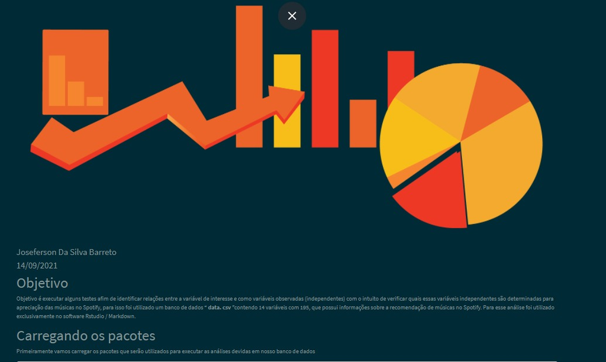

Análise Exploratória na linguagem Python :

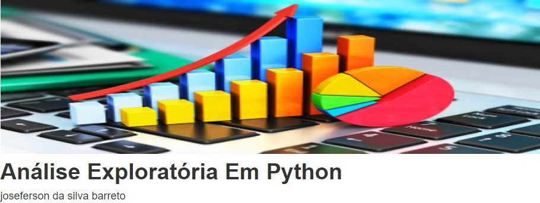